# 7-基础统计学函数与R语言

王梓安

2025-03-01

## 7.1 R函数、选项参数、统计函数

### 7.1.1 常见R函数初探

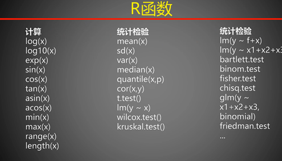

常见R函数

简单介绍一些统计分析时常用的R函数，其余R函数需另行专门学习：

#### 1.lm回归分析

使用lm()函数进行回归分析，例如研究state.x77这个数据，研究犯罪率与其他指标的关系：

```r
# 首先将数据转化为数据框，因为lm()函数只能对数据框进行操作
state <- as.data.frame(state.x77[,c("Murder","Population","Illiteracy","Income","Frost")])
state
# 再使用lm()函数进行回归分析，研究人口、文盲率、收入以及天气对犯罪率的影响：
fit <- lm (Murder ~ Population+Illiteracy+Income+Frost,data=state)
fit
# 使用summary()得出统计结果
summary(fit)
```

#### 2.R函数的输入与输出

- 使用函数要理解输出数据（返回值）的格式：运行结果的输出

```r
# ls()返回当前环境中的对象，也就是有多少变量
ls()
# sys.date()返回当前系统时间
Sys.Date()
# rm()删除environment中指定的变量，但是这个函数是直接删除，不会有返回
a <- 1:100
rm(a)
```

- 使用函数要注意输入数据的格式：输入数据的格式

```r
# 向量：sum,mean,sd,range,median,sort,order
# 矩阵或数据框：cbind,rbind(增加行和列)
# 数字矩阵：heatmap

# 像绘制热图的heatmap，输入数据的格式必须是矩阵；且必须是数值类的，因为heatmap的本质是对数值进行上色
?heatmap

# 像上面的plot函数，输入不同的数据类型，绘制的图像还不一样；如果是向量-向量，就是散点图；如果是向量-因子就是条形图。

# 可以使用help()函数查看每个函数的帮助文档
help(sort)
help(heatmap)
```

[output not shown]

### 7.1.2 函数的选项参数

选项是质，表示是否启用这个参数；参数是量，表示启用的参数设置的值的大小。选项通过T或者F来控制，参数的具体值通过设置的参数值控制；二者共同完成对函数的调控。**而一般来说，函数的选项参数可以进一步分成三个部分：输入控制部分、输出控制部分、调节参数部分**。

#### 1.输入控制部分

输入控制部分负责告诉用户函数能接受哪种类型的数据，这个选项参数往往出现在函数的第一位。比如说：

有些函数的第一位选项参数是“file”，说明使用这个函数你需要输入一个文件；如果是“data”则是需要输入一个数据框。

而“x”代表单独的一个对象，一般都是向量，也可以是矩阵或者列表；“x和y”代表函数需要两个输入变量；“x、y、z”函数需要三个输入变量。

“formula”表示输入的是公式………………（具体查看每个函数的帮助文档）

#### 2.输出控制部分

R中输出控制的选项不多。

#### 3.调节参数(部分)

调节部分千差万别，具体问题具体分析。主要注意的有两部分：

1、要学会根据名字判断选项的作用

color选项：明显用来控制颜色

select：与选择有关

font：与字体有关

font.axis：就是坐标轴的字体

lty：line type(线形)

lwd：line width(线宽度)

method：软件算法

2、选项接受哪些参数：

main：该参数是用来设置标题的，只接受字符串，不能是向量

na.rm：TRUE或者FALSE

axis：该参数用来控制坐标轴的方向，side参数只能是1到4

fig：用来控制图形区域的位置，每次输入该参数必须包含四个元素的向量

…………

示例：

```r
ls("package:base")
par()
length(par())
?sum
?read.table
library(scatterplot3d)
?scatterplot3d
?plot
plot(c(1:20),c(seq(1,89,length.out = 20)),type="l",lty=1)
plot(c(1:20),c(seq(1,89,length.out = 20)),type="l",lty=2)
```

### 7.1.3 数学统计函数

统计是分析的基础，对向量计算的一些基础函数其实已经可以算是统计函数了；如sun、mean等。使用apply系列函数可以将这些原本只能计算向量的函数运用到矩阵、数据框的行列计算上。

#### 1.概率函数

概率论是统计学的基础，R有许多用于处理概率、概率分布以及随机变量的函数；R对每一个概率分布都有一个简称，这个名称用于识别与分布相联系的函数，这部分涉及到很多统计学基础的理论知识，比如随机试验、样本空间、对立与互斥、随机事件与必然事件、概率密度、概率分布等。

##### （1）R中的概率函数(正态分布)

Norm表示正态分布，正态分布是概率分布的一种。以下的dpqr开头所对应的各个函数都是描述正态分布一些重要指标的子函数：

d前缀—概率密度函数；

P前缀—概率分布函数；

q前缀—分位数函数（分布函数的反函数）；

r前缀rnorm—产生相同(指定)分布的随机数；

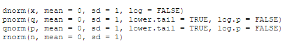

正态分布的特征函数

那如何生成满足正态分布的数字？

```r
# 例如生成一组符合正态分布的随机数，这组数据均值为15，标准差为2，总共100个数据：
rnorm(n=100,mean = 15,sd=2)
```

##### （2）R中的其他概率函数(离散分布……)

同样的道理，在其他类型的分布缩写前面加上d、p、q、r，就变成对应的子函数：比方说离散分布（概率密度函数、概率分布函数、分位数函数、相同分布的随机数）、二项分布、卡方分布、几何分布、超几何分布…………

```r
# 如何查询某个具体分布的原理和特征：

# 几何分布
?Geometric
# 超几何分布
?Hypergeometric
```

#### 2.如何生成函数分布(相同分布的随机数)图像

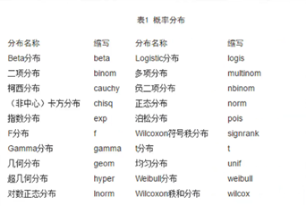

这些分布函数可以帮助我们在R中绘制各种分布函数图，示例如下：

```r
# 生成一个正态分布函数的R对象
x=rnorm(n=100,mean = 15,sd=2)
# 绘制图像
qqnorm(x)

# 这是伽马分布函数
dgamma(c(1:9),shape = 2,rate = 1)
```

[output not shown]

#### 3.R中如何生成随机数

最简单的是runif()函数，可以生成0-1之间的随机数：

```r
# 生成50个0-1之间的随机数
runif(50)
runif(10)*10#生成10个0-10（0-1之间的数*10）之间的数

# 如果想生成0-1之外的随机数，可以通过修改选项参数来更改
runif(50,min=1,max=100)#这样就能生成1-100以内的50个随机数了
```

#### 4.R中如何生成可以复现的随机数

set.seed()函数可以绑定随机数，当输入Set.seed()函数时，回到最初的随机数：

```r
# 先输入seed值，紧接其后runif的数据就可以与其绑定；下次复现这组数据就可以配合seed进行复现：
# 基于seed种子绑定随机值：
set.seed(666)
runif(50)
# 没有种子seed输出的就不是之前定好的随机值了：
runif(50)
# 配合seed种子成功复现了随机值：
set.seed(666)
runif(50)
```

每个set.seed()号码对应的随机数是相同的，这个功能主要是可以在研究发表时重现随机分组，以保证在不同设备上也能独立获得相同的结果。

## 7.2 描述性统计、频数统计和独立性检验

### 7.2.1 描述性统计函数

#### 1.summary函数

首先是summary()函数，运行一次该函数，就可以对数据进行详细的统计。

```r
# 先自定义一个变量R对象，把mtcars的数据赋值给这个变量：
myvars <- mtcars[c("mpg","hp","wt","am")]
# 使用summary()函数计算变量的数据，结果包括最小值，最大值，四分位数和数值型变量的均值：
summary(myvars)
# 在回归分析中也会大量用到summary()函数
```

#### 2.fivenum函数

fivenum()函数和summary()函数类似，但只可以返回5个基本的统计量，包括最小值，四分位数、中位数、上四位数、最大值：

```r
fivenum(myvars$hp)#这里使用了$符取出单个数据列进行统计
```

#### 3.describe函数(Hmisc包)

Hmisc包中的describe()函数也可以计算统计量，可以返回变量和观测的数量、缺失值和唯一值的数目，以及平均值、分位数、已知的五个最大的值和五个最小的值：

```r
# install.packages("Hmisc")
library(Hmisc)
myvars <- c("mpg", "hp", "wt")
describe(mtcars[myvars])
```

#### 4.stat.desc函数(pastecs包)

pastecs包中有一个stat.desc()函数可以计算种类繁多的描述性统计量。stat.desc()函数的选项参数中，x应该是一个数据框或者是时间序列的数据格式，不然函数无法识别：

```r
# install.packages("pastecs")
library(pastecs)
# 如果设置basic选项等于true，那么就会计算一些基本值，包括全部值的数量、空值以及缺失值的数量，最小值、最大值、值域、还有总和：
stat.desc(myvars,basic = T)

# 如果设置desc选项等于true，那么就会计算一些描述值，包括中位数、平均数、平均数的标准误、平均置信度为95%的置信空间、方差、标准差、以及变异系数等：
stat.desc(myvars,desc = T)

# 默认情况下，两个选项参数都是T


# 如果设置norm为T，那么就会计算一些统计值，包括正态分布统计量、偏度和峰度等：
stat.desc(myvars,norm = T)
stat.desc(mtcars,basic = TRUE,desc = TRUE,norm = TRUE)
# 上面两个命令是等价的
```

#### 5.describe函数(psych包)：截尾均值

psych包中也有一个describe()函数，可以计算非缺失值的数量、平均数、标准差、中位数、截尾的均值、最大值、最小值、偏度和峰度等等内容。

- 截尾均值和describe函数：截尾均值是去掉两头的数据取均值，就像打分时，去掉一个最低分、去掉一个最高分，然后中间数据求均值。describe()函数可以通过设置trim参数，设置去除比例，如trim=0.1，则是去除数据中最高和最低的10%的部分。

```r
library(psych)
describe(mtcars[myvars],trim = 0.1)
```

- 不同包的函数重名情况：当两个包的函数名一样时，后面载入的包的函数会覆盖前面载入的包的函数，如果要使用前面一个包的函数，只需要在包后加冒号再使用即可，如下。

```r
Hmisc::describe()
Hmisc::describe(mtcars)
```

#### 6.aggregate函数(MASS包、分组描述)

前面都是对数据进行整体的描述，aggregate函数可以分组描述数据，即aggregate()函数可对数据进行分组描述，能够对数据按照指定的分组信息进行统计；这需要你在输入aggregate函数相关参数时，将分组信息与标准通过一个列表进行指定。

```r
# 例如我们使用mass这个包中的cars93数据集【93年许多不同汽车的指标】
library(MASS)

# 因为该函数只能处理数值型向量，Cars93数据集中的字符型必须被剔除，所以将Cars93[c("Min.Price","Max.Price","MPG.city")选择出来，这里面都是数值型向量以制造商这一列数据为例：
aggregate(Cars93[c("Min.Price","Max.Price","MPG.city")],
          by=list(Manufacturer=Cars93$Manufacturer),mean)
# 这样就是根据汽车制造商来对数据进行分组统计，计算每个汽车制造商产品平均的价格还可以根据产地：
aggregate(Cars93[c("Min.Price","Max.Price","MPG.city")],
          by=list(origin=Cars93$Origin),mean)
# 还可以将mean函数替换成其他函数，比如sd，计算数据的标准差：
aggregate(Cars93[c("Min.Price","Max.Price","MPG.city")],
          by=list(origin=Cars93$Origin),sd)
# 也可以一次性使用多个分组条件，只需要在列表中添加即可，例如同时使用产地和制造商来分组：
aggregate(Cars93[c("Min.Price","Max.Price","MPG.city")],
          by=list(origin=Cars93$Origin,Manufacturer=Cars93$Manufacturer),mean)
```

aggregate函数的缺点是一次只能使用一个统计函数，比如只能返回平均值、方差等。

#### 7.summaryBy函数(doBy包、分组描述)

doBy包中的summaryBy函数，不仅具备了aggregate函数的分组描述数据功能，还针对aggregate的缺点、可以使用一些扩展包来进行分组计算并**返回多种描述性统计量**。

首先是doBy包中的summaryBy()函数：

```r
summary_by(formula, data, id = NULL, FUN = mean..)
```

formulate参数：在波浪线左侧是需要分析的数值型变量，直接写数据框中的列的名字就可以，不需要添加引号，不同变量之间用+号连接；右侧的变量是类别型的分组变量。data参数：指定数据集。fun参数：指定统计函数，也可以是自定义函数。

具体实例如下：

```r
# install.packages("doBy")
library(doBy)
summaryBy(mpg+hp+wt~am, data=mtcars, FUN=mystats)
# Fun参数后面可以接多个统计函数，如
summaryBy(mpg+hp+wt~am,data=myvars,FUN = c(mean,sd,sum))
```

#### 8.describe.by函数(Psych包、分组描述)

Psych包中的describe.by函数，不仅可以实现分组描述数据、和psych包的describe()函数一样能够计算相同的统计量，但是describe.by()函数可以通过分组来计算，只需要添加一个分组的列表，直接给定一个list即可：

```r
library(psych)
describeBy(mtcars[myvars], list(am=mtcars$am))
```

describe.by()适合详细查看每一个分组的统计值，但缺点是给出的统计值是固定不变的，没办法使用自定义的函数。

### 7.2.2 频数统计函数

#### 1.一维的数据框的频率统计

##### （1）频数统计与分组统计

频数统计：频数在数据分析中是非常重要的一个概念，因为统计分析中经常需要进行分组统计，比较不同组之间的差异，这些都要涉及到频数的统计。因子（R的数据类型，一种分组型数据）是专门用来进行分组的，**有因子才能分组，分组之后才能进行频数统计**。

分组统计：然后我们介绍一下R如何对数据进行分组——如果一个数据本身就是因子，那么直接就可以进行分组，例如mtcars数据集，里面的“cyl”这一列数据直接就可以作为因子，依据气缸数的不同来进行分组。

下面是对数据进行**转因子和分组**的实例：

```r
# 用as.factor()函数将这列转换为因子数据：
cylfactors <- as.factor(mtcars$cyl)
# 然后可以使用split()函数对数据进行分组：
myvars <- dplyr::mutate(myvars,cylfactors1=cylfactors)
split(myvars,myvars$cylfactors1)

# 还可以使用cut()函数（如果没有明显的分类），cut可以对连续的数据进行切割，使用cut()函数对“mpg”这列进行分割，根据10-50切成10份，就是以步长为10，每十下一切：
cut(myvars$mpg,c(seq(10,50,10)))#此处seq()函数的选项参数是：seq(from=，to=，by=组距)
```

##### （2）频数分组后如何统计

在分组之后，就可以用table()函数进行频数的统计。table()函数可以计算频数表，也叫列联表，列联表分为一维列联表和多维列联表；table函数同样要求因子这一数据类型：

```r
# table()函数的使用比较简单：
table(myvars$cylfactors1)
# cut()函数的结果也可以使用table()来统计：
table(cut(myvars$mpg,c(seq(10,50,10))))
```

以上（1）（2）步骤就是频数统计的做法。

##### （3）频率如何统计

用频数除以总数就是频率值，R中可以直接使用prop.table()函数计算频率值：

```r
prop.table(table(mtcars$cyl))
prop.table(table(cut(mtcars$mpg,c(seq(10,50,10)))))
```

频率值`*100`就是百分比的结果：

```r
prop.table(table(mtcars$cyl))*100
```

#### 2.二维的数据框的频率统计

上面是一维数据，那么二维的数据框如何进行频率统计呢？

##### （1）table()或as.table()函数

可以使用table()或者as.table()函数，选项参数输入两个因子就可以计算二维数据的频率了。这里我们以vcd包中的风湿病数据集（arthritis）进行示范：

```r
# Arthritis数据集中的“treatment”、“sex”以及“improved”列都可以作为因子数据，因为它们是类型量，我们取两个作统计：
library(vcd)
head(Arthritis)

# 返回的结果是一个二维的列联表，横向是安慰剂组与治疗组的区分，每一列分别是“没有效果”、“有一些效果”、“很有效果”的区分。
table(Arthritis$Treatment,Arthritis$Improved)
```

如果变量太多，我们也可以先使用with()或者是attach()函数先加载数据：

```r
with(data = Arthritis,table(Treatment,Improved))
mytable <- with(Arthritis, table(Treatment,Improved))#这样就不用反复的书写变量名称

mytable#频数
prop.table(mytable)#频率
prop.table(mytable)*100#百分比
```

##### （2）xtabs函数

处理二维列联表还可以使用xtabs()函数，这个函数的好处是它的选项参数使用的是formula参数，这样就可以根据需要写成多种公式。

```r
# 同样是“treatment”以及“improved”列，使用xtabs()函数计算如下：
xtabs(~ Treatment+Improved,data = Arthritis)
# formula参数是可以省略的，结果和with()函数的一致
```

##### （3）margin.table函数(边际频数)和prop.table函数(边际频率)

对于二维列联表我们还可以使用margin.table()和prop.table()函数分别计算边际频数与比例（边际频率）。注：边际频数的意思就是单独按照行或者列的数据进行频数处理。

```r
# 使用margin.table()函数统计边际频数：
# 我们将xtabs()的结果保存到变量x中，再使用margin.table()函数统计一下x:
x <- xtabs(~ Treatment+Improved,data = Arthritis)
margin.table(x)
# 返回值只有一个，代表返回的是所有的结果，这里需要给定一个边际值，1或者2；1代表行，2代表列：
margin.table(x,1)
margin.table(x,2)

# 使用prop.table()函数计算比例（边际频率）：
prop.table(x)#cell proportions（单元格频率）
prop.table(x,1)#row proportions（行频率）
# 从边际和比例的计算结果可以看出，有治疗组有51%的比例是效果显著的，比边际频数41要大，说明药物是有用的。
# 再将margin.table()参数换成2，则是按列进行统计：
prop.table(x,2)#column proportions（列频率）
```

##### （4）addmargins函数

addmargins()函数可以直接将边际(行、列)的和添加到频数表中：

```r
# 将边际(行、列)的和添加到频数表中：
addmargins(x)
# 这个函数也可单独计算行、列：
addmargins(x,1)
addmargins(x,2)
```

#### 3.三维的数据框的频率统计(仍基于xtabs函数)

```r
# 我们也可以计算三维的列联表，加多一个参数就可以：
xtabs(~ Treatment+Improved+Sex,data = Arthritis)
# 结果看起来有点乱，这时候我们可以使用ftable()函数，它能将结果转换为一个平铺式的列联表：
y <-  xtabs(~ Treatment+Improved+Sex,data = Arthritis)
ftable(y)
```